# Clase 4. Datos en Panel - Transiciones de Situación por Hogar.

Natsumi Shokida, Gudio Weksler y Diego Kozlowski

27 de Octubre de 2017

# Transiciones de situación.

En esta clase veremos un ejemplo de trabajo con datos de Panel. El ejercicio consiste en identificar a cada Individuo según su pertenencia a las categorías: *Indigente*, *Pobre* y *No Pobre*, en dos períodos consecutivos.  
Es importante aclarar que los resultado no van a ser los mismos que los publicados, porque el calculo oficial se hace en una base semestral, mientras que este cálculo es una aproximación, en base trimestral.

Comenzamos limpiando la memoria y creando los directorios

```r
rm(list=ls())
dir <- paste0(dirname(rstudioapi::getActiveDocumentContext()$path),"/")
bases.dir      <-  paste0(dirname(dir),"/Fuentes/")
resultados.dir <- paste0(dirname(dir),"/Resultados/")
```

Para el tipo especial de gráficos, utilizamos el paquete *alluvial*

```r
library(alluvial, warn=FALSE)
library(tidyverse, warn=FALSE)
library(readxl, warn=FALSE)
library(questionr, warn=FALSE)
```

Levantamos las Bases Individuales de 2 trimestres consecutivos.  
A su vez levantamos fuentes secundarias con información de la canasta alimentaria y la canasta total, categorías de Adulto equivalente, y códigos de regiones y aglomerados.  
La información de estas tablas la podemos sacar del [comunicado de pobreza](http://www.indec.gob.ar/uploads/informesdeprensa/eph_pobreza_02_16.pdf).

```r
individual.316 <- read.table(paste0(bases.dir, "usu_individual_t316.txt"), sep=";", dec=",", header = TRUE, fill = TRUE)
individual.416 <- read.table(paste0(bases.dir, "usu_individual_t416.txt"), sep=";", dec=",", header = TRUE, fill = TRUE)
Adequi <- read_excel(paste0(bases.dir,"ADEQUI.xls"))
Adequi
```

| CH04 | CH06 | adequi |
| --- | --- | --- |
| 1 | -1 | 0.35 |
| 1 | 1 | 0.37 |
| 1 | 2 | 0.46 |
| 1 | 3 | 0.51 |
| 1 | 4 | 0.55 |
| 1 | 5 | 0.60 |
| 1 | 6 | 0.64 |
| 1 | 7 | 0.66 |
| 1 | 8 | 0.68 |
| 1 | 9 | 0.69 |

[output cut: 212 more lines]

```r
CBA <- read_excel(paste0(bases.dir,"CANASTAS.xls"),sheet = "CBA")
CBA
```

| Año | Mes | GBA | Pampeana | Noroeste | Noreste | Cuyo | Patagonia |
| --- | --- | --- | --- | --- | --- | --- | --- |
| 2016 | 7 | 1666.48 | 1660.19 | 1458.24 | 1496.21 | 1494.04 | 1713.67 |
| 2016 | 8 | 1675.05 | 1662.99 | 1459.38 | 1501.91 | 1496.09 | 1723.86 |
| 2016 | 9 | 1711.22 | 1705.31 | 1498.62 | 1540.68 | 1536.29 | 1767.89 |
| 2016 | 10 | 1739.34 | 1731.84 | 1516.82 | 1559.51 | 1559.00 | 1797.44 |
| 2016 | 11 | 1762.65 | 1753.27 | 1532.67 | 1573.18 | 1577.67 | 1819.64 |
| 2016 | 12 | 1766.62 | 1754.08 | 1526.86 | 1571.59 | 1574.22 | 1822.96 |

```r
CBT <- read_excel(paste0(bases.dir,"CANASTAS.xls"),sheet = "CBT")
CBT
```

| Año | Mes | GBA | Pampeana | Noroeste | Noreste | Cuyo | Patagonia |
| --- | --- | --- | --- | --- | --- | --- | --- |
| 2016 | 7 | 4032.88 | 4017.66 | 3281.04 | 3396.40 | 3854.62 | 4712.59 |
| 2016 | 8 | 4036.87 | 4007.81 | 3269.01 | 3394.32 | 3844.95 | 4723.38 |
| 2016 | 9 | 4089.82 | 4075.69 | 3326.94 | 3451.12 | 3917.54 | 4790.98 |
| 2016 | 10 | 4191.81 | 4173.73 | 3397.68 | 3524.49 | 4006.63 | 4924.99 |
| 2016 | 11 | 4247.99 | 4225.38 | 3417.85 | 3539.66 | 4038.84 | 4967.62 |
| 2016 | 12 | 4257.55 | 4227.33 | 3420.17 | 3551.79 | 4045.75 | 4994.91 |

```r
dic.regiones <- read_excel(paste0(bases.dir,'Regiones.xlsx'))
dic.regiones
```

| Region | REGION |
| --- | --- |
| GBA | 1 |
| Pampeana | 43 |
| Noroeste | 40 |
| Noreste | 41 |
| Cuyo | 42 |
| Patagonia | 44 |

## Canastas Trimestrales por Region

A partir de los datos mensuales de la Canasta Básica Alimentaria y Total publicados por INDEC, calculamos un valor trimestral de ambas canastas, para un Adulto Equivalente perteneciente a cada una de las regiones.

```r
CBA$Canasta <- 'CBA'
CBT$Canasta <- 'CBT'
Canasta <- bind_rows(CBA,CBT)                            %>%
  gather(.,Region, Valor, c(3:(ncol(.)-1) ))             %>%
  mutate(Trimestre = case_when(Mes %in% c(1:3)   ~1,
                               Mes %in% c(4:6)   ~2,
                               Mes %in% c(7:9)   ~3,
                               Mes %in% c(10:12) ~4),
         Periodo = paste(Año, Trimestre, sep='.'))       %>%
  group_by(Canasta, Region, Periodo)                     %>%
  summarise(Valor = mean(Valor))                         %>%
  spread(., Canasta,Valor)                               %>%
  left_join(., dic.regiones, by = "Region")              %>%
  ungroup()                                              %>%
  select(-Region)
Canasta
```

| Periodo | CBA | CBT | REGION |
| --- | --- | --- | --- |
| 2016.3 | 1508.807 | 3872.370 | 42 |
| 2016.4 | 1570.297 | 4030.407 | 42 |
| 2016.3 | 1684.250 | 4053.190 | 1 |
| 2016.4 | 1756.203 | 4232.450 | 1 |
| 2016.3 | 1512.933 | 3413.947 | 41 |
| 2016.4 | 1568.093 | 3538.647 | 41 |
| 2016.3 | 1472.080 | 3292.330 | 40 |
| 2016.4 | 1525.450 | 3411.900 | 40 |
| 2016.3 | 1676.163 | 4033.720 | 43 |
| 2016.4 | 1746.397 | 4208.813 | 43 |

[output cut: 2 more lines]

Armamos un vector que contiene las variables relevantes para el ejercicio. Para luego seleccionar de la tabla solo las mismas.

```r
var.ind <- c('CODUSU', 'ANO4','TRIMESTRE','NRO_HOGAR','COMPONENTE','REGION',
             'AGLOMERADO', 'PONDERA', 'CH04', 'CH06', 'ITF', 'PONDIH','P21')
```

## Calculo de las Unidades de Adulto Equivalente por hogar, en la base Individual

1. Chequeamos la consistencia entre los individuos entre un período y otro. Para ello utilizamos la función **lead** para observar las características de los individuos en en t+1.
2. Incorporamos a cada registro de nuestra base la Unidad de Adulto Equivalente (UAE) correspondiente, matcheando las columnas de Edad (CH06) y género (CH04) mediante la función **left_join**.
3. Utilizamos la función **group_by** para calcular el total de UAE por hogar. Notesé que al usar la función **mutate** creamos una nueva columna, permitiendo conservar la dimensión individual de la base.
4. En base a las UAE del hogar al que pertenece cada individuo calculamos el valor de las canastas que delimitan las lineas de pobreza e indigencia correspondientes.
5. Realizamos la comparación lógica entre el Ingreso Total Familiar y las Canastas calculadas para asignar a cada individuo su “situación” mediante la función **case_when**.

```r
Pobreza_Individual <- bind_rows(individual.316        %>%
                          select(var.ind),
                        individual.416                %>%
                          select(var.ind))                      %>%
  mutate(Periodo = paste(ANO4, TRIMESTRE, sep='.'))             %>%
  group_by(CODUSU,NRO_HOGAR,COMPONENTE)                         %>%
  mutate(CH06_Diff   = abs(lead(CH06) - CH06)<3,
         CH04_Diff   = lead(CH04==CH04),
         Consistencia=  ifelse((CH06_Diff & CH04_Diff)== FALSE,
                               "inconsistente","consistente"))  %>%
  ungroup()                                                     %>%
  left_join(., Adequi, by = c("CH04", "CH06"))                  %>%
  group_by(CODUSU, NRO_HOGAR, Periodo)                          %>%
  mutate(Adequi_hogar = sum(adequi))                            %>%
  ungroup()                                                     %>%
  left_join(., Canasta, by = c("REGION", "Periodo"))            %>%
  mutate(CBA = CBA*Adequi_hogar,
         CBT = CBT*Adequi_hogar,
         Situacion = case_when(ITF<CBA            ~ 'Indigente',
                               ITF>=CBA & ITF<CBT ~ 'Pobre',
                               ITF>=CBT           ~ 'No.Pobre'))
Pobreza_Individual
```

| CODUSU | ANO4 | TRIMESTRE | NRO_HOGAR | COMPONENTE | REGION | AGLOMERADO | PONDERA | CH04 | CH06 | ITF | PONDIH | P21 | Periodo | CH06_Diff | CH04_Diff | Consistencia | adequi | Adequi_hogar | CBA | CBT | Situacion |
| --- | --- | --- | --- | --- | --- | --- | --- | --- | --- | --- | --- | --- | --- | --- | --- | --- | --- | --- | --- | --- | --- |
| TQRMNOQWXHLMMLCDEFIAH00469008 | 2016 | 3 | 1 | 3 | 43 | 2 | 561 | 1 | 17 | 24000 | 1344 | 0 | 2016.3 | NA | NA | NA | 1.04 | 2.80 | 4693.257 | 11294.416 | No.Pobre |
| TQRMNORPTHJMKTCDEFIAH00469111 | 2016 | 3 | 1 | 1 | 43 | 2 | 569 | 1 | 50 | 0 | 0 | -9 | 2016.3 | NA | NA | NA | 1.00 | 3.52 | 5900.095 | 14198.694 | Indigente |
| TQRMNORPTHJMKTCDEFIAH00469111 | 2016 | 3 | 1 | 2 | 43 | 2 | 569 | 2 | 48 | 0 | 0 | 0 | 2016.3 | NA | NA | NA | 0.76 | 3.52 | 5900.095 | 14198.694 | Indigente |
| TQRMNORPTHJMKTCDEFIAH00469111 | 2016 | 3 | 1 | 3 | 43 | 2 | 569 | 2 | 23 | 0 | 0 | 0 | 2016.3 | NA | NA | NA | 0.76 | 3.52 | 5900.095 | 14198.694 | Indigente |
| TQRMNORPTHJMKTCDEFIAH00469111 | 2016 | 3 | 1 | 4 | 43 | 2 | 569 | 1 | 15 | 0 | 0 | 0 | 2016.3 | NA | NA | NA | 1.00 | 3.52 | 5900.095 | 14198.694 | Indigente |
| TQRMNORPUHJMKTCDEFIAH00469112 | 2016 | 3 | 1 | 1 | 43 | 2 | 569 | 2 | 55 | 62000 | 1105 | 23000 | 2016.3 | NA | NA | NA | 0.76 | 1.76 | 2950.047 | 7099.347 | No.Pobre |
| TQRMNORPUHJMKTCDEFIAH00469112 | 2016 | 3 | 1 | 2 | 43 | 2 | 569 | 1 | 34 | 62000 | 1105 | 18000 | 2016.3 | NA | NA | NA | 1.00 | 1.76 | 2950.047 | 7099.347 | No.Pobre |
| TQRMNOTPSHJMKTCDEFIAH00469114 | 2016 | 3 | 1 | 1 | 43 | 2 | 569 | 1 | 70 | 0 | 0 | 0 | 2016.3 | NA | NA | NA | 0.83 | 2.27 | 3804.891 | 9156.544 | Indigente |
| TQRMNOTPSHJMKTCDEFIAH00469114 | 2016 | 3 | 1 | 2 | 43 | 2 | 569 | 2 | 61 | 0 | 0 | 4000 | 2016.3 | NA | NA | NA | 0.67 | 2.27 | 3804.891 | 9156.544 | Indigente |
| TQRMNOTPSHJMKTCDEFIAH00469114 | 2016 | 3 | 1 | 3 | 43 | 2 | 569 | 2 | 17 | 0 | 0 | 0 | 2016.3 | NA | NA | NA | 0.77 | 2.27 | 3804.891 | 9156.544 | Indigente |

[output cut: 990 more lines]

## Armado de Paneles

Dada la estructura de rotación de la muestra de la EPH, solo la mitad de los hogares permanece en la muestra en dos trimestres consecutivos. Por ende identificamos a aquellos hogares que entraron en ambas muestras. Para eso, utilizamos las función **lag** **(lead)** que sirve para obtener el valor anterior (posterior) de una variable en el Dataframe. Al estar trabajando de manera agrupada por hogar, podemos chequear si existe un valor con determinado CODUSU en el período siguiente o no.

Una vez identificados los hogares que permanecen en la muestra, con la función **lead** podemos crear una variable de Situación_t1.

```r
Panel_Ind <- Pobreza_Individual %>%
  filter(PONDIH>0) %>%
#Si no saco estos me queda gente que en alguno de los dos periodos no respondio ingresos y distorsiona todo
  group_by(CODUSU, NRO_HOGAR, COMPONENTE) %>%
  arrange(Periodo) %>%
  mutate(Cod.Panel = as.factor(ifelse(!is.na(lead(Periodo)),1,0)),
         Situacion_t1 = lead(Situacion)) %>%
         filter(Cod.Panel == 1,Consistencia=="consistente")
Panel_Ind
```

| CODUSU | ANO4 | TRIMESTRE | NRO_HOGAR | COMPONENTE | REGION | AGLOMERADO | PONDERA | CH04 | CH06 | ITF | PONDIH | P21 | Periodo | CH06_Diff | CH04_Diff | Consistencia | adequi | Adequi_hogar | CBA | CBT | Situacion | Cod.Panel | Situacion_t1 |
| --- | --- | --- | --- | --- | --- | --- | --- | --- | --- | --- | --- | --- | --- | --- | --- | --- | --- | --- | --- | --- | --- | --- | --- |
| TQRMNOQRPHMLKPCDEFIAH00487635 | 2016 | 3 | 1 | 1 | 43 | 2 | 698 | 1 | 23 | 6500 | 760 | 0 | 2016.3 | TRUE | TRUE | consistente | 1.02 | 1.02 | 1709.687 | 4114.394 | No.Pobre | 1 | No.Pobre |
| TQRMNOQTRHMKKQCDEFIAH00487636 | 2016 | 3 | 1 | 1 | 43 | 2 | 993 | 1 | 21 | 10000 | 1794 | 0 | 2016.3 | TRUE | TRUE | consistente | 1.02 | 2.04 | 3419.373 | 8228.789 | No.Pobre | 1 | No.Pobre |
| TQRMNOQTRHMKKQCDEFIAH00487636 | 2016 | 3 | 1 | 2 | 43 | 2 | 993 | 1 | 24 | 10000 | 1794 | 0 | 2016.3 | TRUE | TRUE | consistente | 1.02 | 2.04 | 3419.373 | 8228.789 | No.Pobre | 1 | No.Pobre |
| TQRMNOQRSHMOMMCDEFIAH00487638 | 2016 | 3 | 1 | 1 | 43 | 2 | 775 | 2 | 46 | 23000 | 1791 | 8000 | 2016.3 | TRUE | TRUE | consistente | 0.76 | 2.76 | 4626.211 | 11133.067 | No.Pobre | 1 | No.Pobre |
| TQRMNOQRSHMOMMCDEFIAH00487638 | 2016 | 3 | 1 | 2 | 43 | 2 | 775 | 1 | 54 | 23000 | 1791 | 15000 | 2016.3 | TRUE | TRUE | consistente | 1.00 | 2.76 | 4626.211 | 11133.067 | No.Pobre | 1 | No.Pobre |
| TQRMNOQRSHMOMMCDEFIAH00487638 | 2016 | 3 | 1 | 3 | 43 | 2 | 775 | 1 | 15 | 23000 | 1791 | 0 | 2016.3 | TRUE | TRUE | consistente | 1.00 | 2.76 | 4626.211 | 11133.067 | No.Pobre | 1 | No.Pobre |
| TQRMNORUVHMOMMCDEFIAH00487641 | 2016 | 3 | 1 | 1 | 43 | 2 | 775 | 1 | 33 | 9800 | 1415 | 8400 | 2016.3 | TRUE | TRUE | consistente | 1.00 | 3.33 | 5581.624 | 13432.288 | Pobre | 1 | Pobre |
| TQRMNORUVHMOMMCDEFIAH00487641 | 2016 | 3 | 1 | 2 | 43 | 2 | 775 | 2 | 34 | 9800 | 1415 | 500 | 2016.3 | TRUE | TRUE | consistente | 0.77 | 3.33 | 5581.624 | 13432.288 | Pobre | 1 | Pobre |
| TQRMNORUVHMOMMCDEFIAH00487641 | 2016 | 3 | 1 | 3 | 43 | 2 | 775 | 1 | 10 | 9800 | 1415 | 0 | 2016.3 | TRUE | TRUE | consistente | 0.79 | 3.33 | 5581.624 | 13432.288 | Pobre | 1 | Pobre |
| TQRMNORUVHMOMMCDEFIAH00487641 | 2016 | 3 | 1 | 4 | 43 | 2 | 775 | 2 | 17 | 9800 | 1415 | 0 | 2016.3 | TRUE | TRUE | consistente | 0.77 | 3.33 | 5581.624 | 13432.288 | Pobre | 1 | Pobre |

[output cut: 990 more lines]

## Cálculo de Tasas de Pobreza e Indigencia - Base completa y Panel

```r
Pobreza_resumen <- Pobreza_Individual %>%
  group_by(Periodo) %>%
  summarise(Tasa_pobreza    = sum(PONDIH[Situacion %in% c('Pobre', 'Indigente')],na.rm = TRUE)/
                              sum(PONDIH,na.rm = TRUE),

            Tasa_indigencia = sum(PONDIH[Situacion == 'Indigente'],na.rm = TRUE)/
                              sum(PONDIH,na.rm = TRUE))
Pobreza_resumen
```

| Periodo | Tasa_pobreza | Tasa_indigencia |
| --- | --- | --- |
| 2016.3 | 0.3069060 | 0.06615618 |
| 2016.4 | 0.2999601 | 0.05682831 |

```r
Pobreza.panel <- Panel_Ind %>%
  group_by(Periodo) %>%
  summarise(Tasa_pobreza    = sum(PONDIH[Situacion %in% c('Pobre', 'Indigente')],na.rm = TRUE)/
                              sum(PONDIH,na.rm = TRUE),

            Tasa_indigencia = sum(PONDIH[Situacion == 'Indigente'],na.rm = TRUE)/
                              sum(PONDIH,na.rm = TRUE))
Pobreza.panel
```

| Periodo | Tasa_pobreza | Tasa_indigencia |
| --- | --- | --- |
| 2016.3 | 0.2859461 | 0.0526925 |

## Grafico de Transición

Para realizar el gráfico de transición, utilizaremos el paquete **alluvial**, con la función homónima.  
Para ello debemos construir un Dataframe que contenga la cantidad de casos observado para cada posible transición. Utilizamos el Ponderador de Ingresos (PONDIH).  
Adicionalmente, reescribimos como factores a las variables de Situación, para ordenar su aparición en el gráfico.

```r
datos.alluvial <- Panel_Ind %>%
  group_by(Situacion,Situacion_t1, REGION) %>%
  summarise(frecuencia = sum(PONDIH),
            n_muestral = n()) %>%
  left_join(.,dic.regiones, by= "REGION") %>%
  arrange(REGION)
datos.alluvial$Situacion <- factor(datos.alluvial$Situacion, levels =
                                         c("No.Pobre","Pobre","Indigente"))
datos.alluvial$Situacion_t1 <- factor(datos.alluvial$Situacion_t1, levels =
                                         c("No.Pobre","Pobre","Indigente"))
datos.alluvial
```

| Situacion | Situacion_t1 | REGION | frecuencia | n_muestral | Region |
| --- | --- | --- | --- | --- | --- |
| Indigente | Indigente | 1 | 99415 | 64 | GBA |
| Indigente | No.Pobre | 1 | 23021 | 14 | GBA |
| Indigente | Pobre | 1 | 76954 | 58 | GBA |
| No.Pobre | Indigente | 1 | 46490 | 23 | GBA |
| No.Pobre | No.Pobre | 1 | 2557133 | 1277 | GBA |
| No.Pobre | Pobre | 1 | 283673 | 146 | GBA |
| Pobre | Indigente | 1 | 89551 | 56 | GBA |
| Pobre | No.Pobre | 1 | 263347 | 130 | GBA |
| Pobre | Pobre | 1 | 340025 | 195 | GBA |
| Indigente | Indigente | 40 | 21484 | 90 | Noroeste |

[output cut: 44 more lines]

## Loop de Gráficos

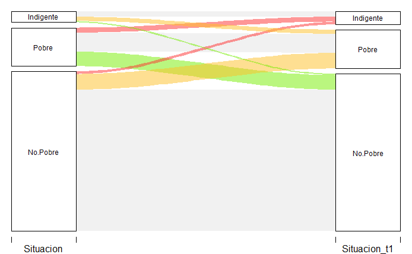

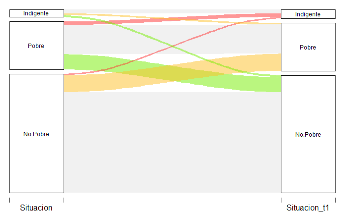

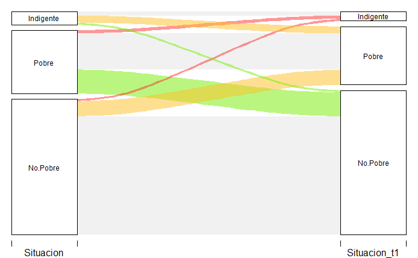

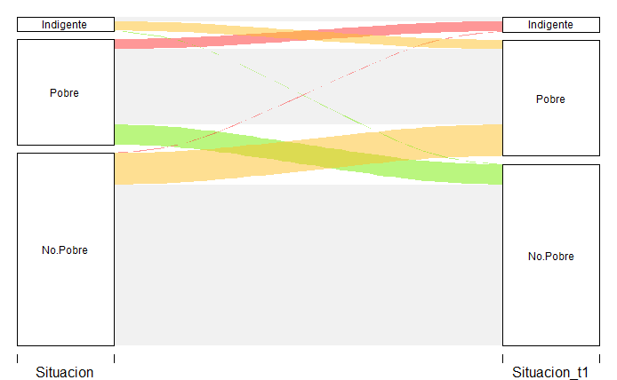

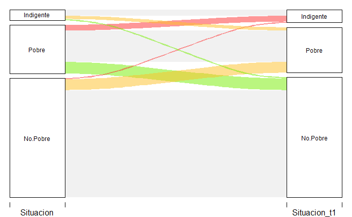

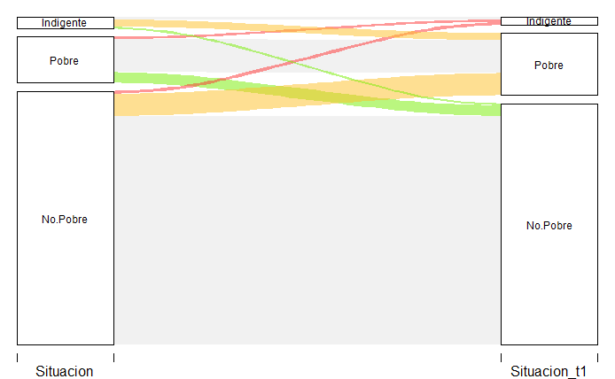

```r
# pdf(paste(resultados.dir, "Transiciones de Situación - Regiones - t316-t416.pdf", sep = ""), onefile = T)
for(Reg in unique(datos.alluvial$REGION)){

  data.Reg <- datos.alluvial %>% filter(REGION == Reg)
  tmp.nom <- dic.regiones$Region[dic.regiones$REGION==Reg]
  colores <- ifelse(data.Reg$Situacion==data.Reg$Situacion_t1,"gray90",
                    ifelse(data.Reg$Situacion_t1=="Indigente","firebrick1",
                           ifelse(data.Reg$Situacion_t1 == 'Pobre','goldenrod1',
                                  ifelse(data.Reg$Situacion_t1 == 'No.Pobre','chartreuse2','red'))))

  transiciones <- alluvial(data.Reg[,c(1:2)], freq=data.Reg$frecuencia, border=NA,
                           col = colores, cex=0.75, xw=.15)
  mtext(paste0('Region: ',tmp.nom), 3, line=3, font=2)
  paste(Sys.time(),tmp.nom)
}
```

```r
# dev.off()
```